# Project Report

Group 22

2023-11-09

## 1. Introduction

### 1.1 About Cricket

What is the first thing that comes to your mind when you hear, see the word “CRICKET”?

We probably think about cricket match so we decided to make a a shiny app that takes two teams and gives us the result of the match .

### 1.2 Project Motivation & Objective

We are motivated by the craze of cricket , World Cup are going on and we see the match and thought come in mind that what happen if in a team one or two player are changed , what will be the probablity of winning , So based of previous data we decided to make a function that will do our job .

### 1.3 Questions We Imposed

Here are a few questions laid down by us looking at the dataset:

- What level of control and customization is available during the match simulation?
- Can we get a visual representations of data using graphs and chart?
- Can we filter match history by specific teams, years, or tournaments?
- Are historical statistics and records available for past World Cup tournaments?
- Can we view a team’s recent performance statistics, such as recent form and trends?
- What is the correlation between a country’s performance and its GDP and its Happiness index?
- How can we access a summary of each previous encounter between two sides in the app?
- Is there a feature to watch or re-enact classic matches from the past?
- Can we find the win-loss ratio for different countries participating in the ODI World Cup?
- Can we choose between default teams or create a custom team with my favorite players?

## 2. About our Dataset

### 2.1 Source and method of obtaining dataset

There are many websites witch stores data of cricket player and teams we scraph the data from such a website called **CricMetric**

### 2.2 Describing datsaset variables

The dataset we obtained was having data of all the ODI cricket player of all the teams that playes of had played ODI matches , we selected those player witch are playing now becouse we got the list of player of ODI team of every country that have ODI team .

#### 2.2.1 Categorical Variables

**Player_name**

Contains the name of playes according to country and saved as a list .

**Country_name**

Contains the names of country witch are interested in ODI means have ODI teams and are going to play ODI matched .

**All_Player_name**

Contain same as Player name but in different manner this have player name in simple way means as a vector .

#### 2.2.2 Numerical Variables

**All_Player_Data**

This variable is a list witch contains 147 list whose names are according to Player names and in each list scraped data is stored . We scraph data in form of a tibble and computed probablity of from that and and also a visualsation plot and store all these in a list means in list that is of player name contaion all these three things .

**coord**

Contains the coordinated of world by this we will plot the world map and show some visualisation on it .

**gdp**

This is a data set Which have row names as country name and columns have years and have gdp data in it .

**happy**

This is a dataset witch have row as country name and columns are year rank and index and data in it

**image_links**

This is a list in this there are 10 list named after country name and in each there are 15 list which have name before player name and in this image ink is stored .

**Player_Data**

Is a list conatin the data witch is same as All_Player_data but saved according to country names.

**table**

Contains Win and loose ratio of the teams in past matches .

## 3. How did we obtain our dataset? (Scraping it is!)

### 3.1 Libraries we used in this process

- rvest
- tidyverse

### 3.2 Problems we faced in this process

The main problem is that when we scrap the player name and in **Crickmetric** website we put a player name and it says no data becouse there is a spell mistake in the name and on other website same happens with different player name.

### 3.3 Solutions we used to tackle the aforementioned issues

so after scraping we croos check the names of a player mainually , after getting the correct name we formed the list and makes a function the scrap the data a give input as a player name and takes output the dataset of the past years . The GDP per Capital data was initially downloaded from - [kaggle](https://www.kaggle.com/datasets/zgrcemta/world-gdpgdp-gdp-per-capita-and-annual-growths?select=gdp_per_capita.csv). It is cleaned to be used with the dataset collected. The Happiness Index data was downloaded from - [kaggle](https://www.kaggle.com/datasets/simonaasm/world-happiness-index-by-reports-2013-2023/?select=World+Happiness+Index+by+Reports+2013-2023+with+nulls.csv).

## 4. Cleaning the Dataset

### 4.1 Libraries we used in this process

- dplyr
- stringr

### 4.2 Method, problems and their solutions while cleaning data

#### 4.2.1 Player Data

When we see all payer are now matching with the website player name then after checking 2-3 player name we see the the data which website is showing is in same way so we deside to form a function that will scraph al the data , the cleaning of data will also present in th function , the main problem is that the NA values are generting in cleaning process becouse of some sign , we use gsum , sub , substering, sapply , etc functions to clean the data

#### 4.2.2 Categorizing numeric into category

All the data we get from the website is in formet of character so we convert all the data in numeric category . so that we can use it in visualisation .

#### 4.2.3 Functions that are user defined and used in scraping

#### 4.2.3.1 Scrap_Bowling_data(Player name )

This function takes the player name and then from web site scrap the data and clean it and also calculationg the proablity of Bowler players to take witcket and also visulaise the data and combine in a list and give this list as output .

#### 4.2.3.1 Scrap_Bating_data(Player name )

This function takes the player name and then from web site scrap the data and clean it and also calculationg the proablity of players to hit runs and also visulaise the data and combine in a list and give this list as output .

## 5. Cricket Function that simulated the match :

This function takes four input two are player name and two are player data , baised of probablity of players the resyltes are calculated , now i will explain all the codes :

```r
Cricket_Match <- function(Team_Data_1 , Team_Data_2,Team_name_1,Team_name_2){
# here will make a function that will semulates a cricket match

{
  ball <- NULL          # defing ball as null to get values in it

  for(i in 1:11){
  # for i in 1:11 means there are 11 players in a team but will select 5 best bowlers
    tryCatch({
      ball[i] <- Team_Data_2[[i]]$Bowling[[1]]
    }, error=function(e){})
  }
  ball[is.na(ball)] <- 0

  bowler_seq <- NULL
  for ( i in 1:5){
    bowler_seq[i] <- which(ball == max(ball), arr.ind = TRUE)[1]
    ball[bowler_seq[i]] <- 0
  }




  Baller_name <- NULL
  # defining some variable that we will use in the function
  Ball_runs <- NULL
  B_wicket <- NULL

  Order <- rep(bowler_seq,10)
  # this sequence is make to define the order of bowling


  batsman_name <- NULL
  Batsman_6 <- NULL
  Batsman_4 <- NULL
  batsman_run <- NULL
  batsman_outer <- NULL



  Runs <- 0
  Ind <- 1

  for(i in 1:50){
    # i is the no of ovwers here that will be 50 and it will take one by one all
    # the values

    if(Ind == 11){
      break
      # this is for when 10 player got out and 11 player came to bets that
      #the match will be over and so we beak the loop at 11
    }
    over <- NULL           # this will bw used to take data of oveers in it


    Or <- Order[i]

    Wicket <- 0


    for(j in 1:6){
      # here j is the no of ball in  a over
      if(Ind == 11){
        # this is also same when 11 player come to bet the loop will break
        # and function will stop so that match will stop
        break
      }
      # We defined the values zero so that is this variable in function not
      # take any value then NA will not come zero will come if it takes value that
      # it will be replaced
      batsman_run[6*(i-1) + j] <- 0
      Batsman_6[6*(i-1) + j] <- 0
      Batsman_4[6*(i-1) + j] <- 0
      # here we take a sample of out or not on based of probablities that
      # we calculated by data that was scraped
      Sam <- sample(c("Out","Not_Out"),1,replace = TRUE,prob =
                      c(Team_Data_2[[Or]]$Bowling[[1]],
                        1-Team_Data_2[[Or]]$Bowling[[1]]))

       # what if player will not out obeviously it will hit some runs or zero can
      # be there
       if(Sam == "Not_Out"){
      #   print(Team_Data_1[[Ind]]$Batting[[1]])
        # this is the sample witch is based of players probablity to hit runs
         # according to previoud data
        Run <- sample(c(0,1,2,3,4,6),1,replace = TRUE,prob =
                        Team_Data_1[[Ind]]$Batting[[1]])


         Runs <- Runs + Run
        over[j] <- Run                      ##### here we will store the values in
        #variables
        batsman_name[6*(i-1) + j] <- Team_name_1[Ind]
        batsman_run[6*(i-1) + j] <- Run
        # we know when there are 1 or 3 run strike changes that we have done here
        if(Run == 1 || Run == 3){


          nam <- Team_name_1[Ind]
          nam_ <- Team_name_1[Ind + 1]
          Team_name_1[Ind + 1] <- nam
          Team_name_1[Ind] <- nam_



          Runner <- Team_Data_1[[Ind]]$Batting
          Facer <-Team_Data_1[[Ind +1]]$Batting
          Team_Data_1[[Ind+1]]$Batting <- Runner
          Team_Data_1[[Ind]]$Batting <- Facer

        }


        if (Run == 4){                    # if 4 runs we will store it in a
          # variable
          Batsman_4[6*(i-1)+j] <- 1
        }


        if (Run == 6){                       # this is for 6
          Batsman_6[6*(i-1)+j] <- 1
        }



      }

      else {

        batsman_name[6*(i-1) + j] <- Team_name_1[Ind]
        # what if player got out       # here we store wicket and bowlers name
        batsman_outer[6*(i-1)+j] <- Team_name_2[Or]
        Ind <- Ind + 1
        Wicket <- Wicket + 1
        over[j] <- 0
      }
      if (j == 6 ){
        # this is the last ball of the over,strike will change so we do it here

        nam <- Team_name_1[Ind]
        nam_ <- Team_name_1[Ind + 1]
        Team_name_1[Ind + 1] <- nam
        Team_name_1[Ind] <- nam_


        B_wicket[i] <- Wicket
        Baller_name[i] <- Team_name_2[Or]
        Ball_runs[i] <- sum(over)

        Runner <- Team_Data_1[[Ind]]$Batting
        Facer <-Team_Data_1[[Ind +1]]$Batting
        Team_Data_1[[Ind+1]]$Batting <- Runner
        Team_Data_1[[Ind]]$Batting <- Facer

        # Over_Data[[i]] <- Over
      }


     }




    }

    baller_data <- tibble(Baller_name, Ball_runs,B_wicket )
    # here we make tibble of all the data that a got from above loops
    baller_data <- baller_data %>%
      # here we arrange then in a useful way
      group_by(Baller_name) %>%
      summarise(Runs = sum(Ball_runs),
                Wicket = sum(B_wicket)) %>%
      arrange(desc(Wicket))


    batsman_data <- tibble( batsman_name, Batsman_6 ,Batsman_4,batsman_run )
    batsman_data <- batsman_data %>%
      # this is of batsman data
      group_by(batsman_name) %>%
      summarise(six = sum(Batsman_6),
                four = sum(Batsman_4),
                Runs = sum(batsman_run))

    batsman_outer <- as.vector(na.omit(batsman_outer))
    len <- dim(batsman_data)[1]
    # some na are introduced so we removed them

    if( length(batsman_outer) != len){
      for ( i in {length(batsman_outer) + 1}:len){
        batsman_outer[i] <- "Not Out"
      }
    }
    batsman_data$batsman_outer <- batsman_outer



    team_1_run <- sum(batsman_data$Runs)
    # savinf all useful thing in a list so we can take them in a return
    team_2_wicket <- sum(baller_data$Wicket)

    output_1 <- list(length(2))
    output_1[[1]] <- batsman_data
    output_1[[2]] <- baller_data
  }
  #####################
  # Team 2 Bats
  # here, the same process for inning 2  so i will skip
  ####################

}
```

## 5.0 Visualising the Dataset

### 5.1 Libraries we used in this process

- ggplot2
- imager
- rvest
- ggpubr
- ggthemes
- tidyverse
- reshape2

### 5.2 Generating plot with the help of user defined functions

#### 5.2.1 Function: All_Player_data$...$….$[[3]]

In this plot there are two coloured bars , rech are marked in right side of plot anyone can easily understand, the text on red coloured bar is of strike rate in that year and text on blue colured bar shows the rate that player out means in 1 inning what will be the probablity of player to br out is there .

#### 5.2.2 Function: imager(link of image )

This function plot the image of the player by using the link .

### 5.3 Shiny app

The Shiny App made by our group had the following features:

- ODI Player data tab in this tab viwer have to give input as a country name and player name and player data will be shown

[figure not shown]

- ODI team data tab by selection the year viwer can see the relevent output in the side as a tibble as a as plot and visualisation also .

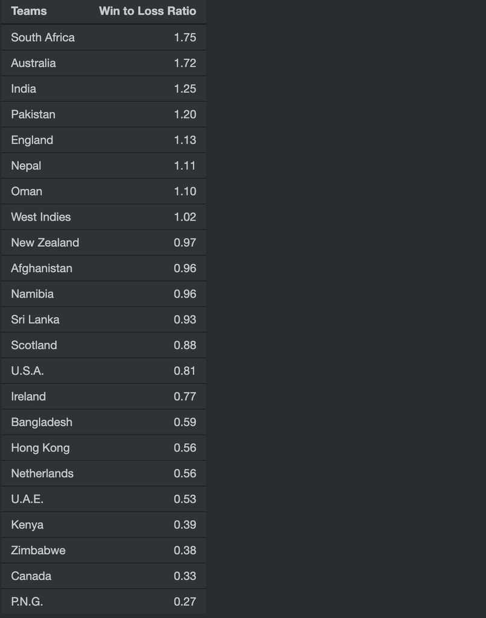

- Match tab In this tab player have to select the team baisd on that output will be genereted by using the *Cricket_Match* and viwer can also define a new team by selecting new team .

[figure not shown]

### 5.4 Generating visualisations using our Shiny App

#### 5.4.1 A bar plot shows the player data

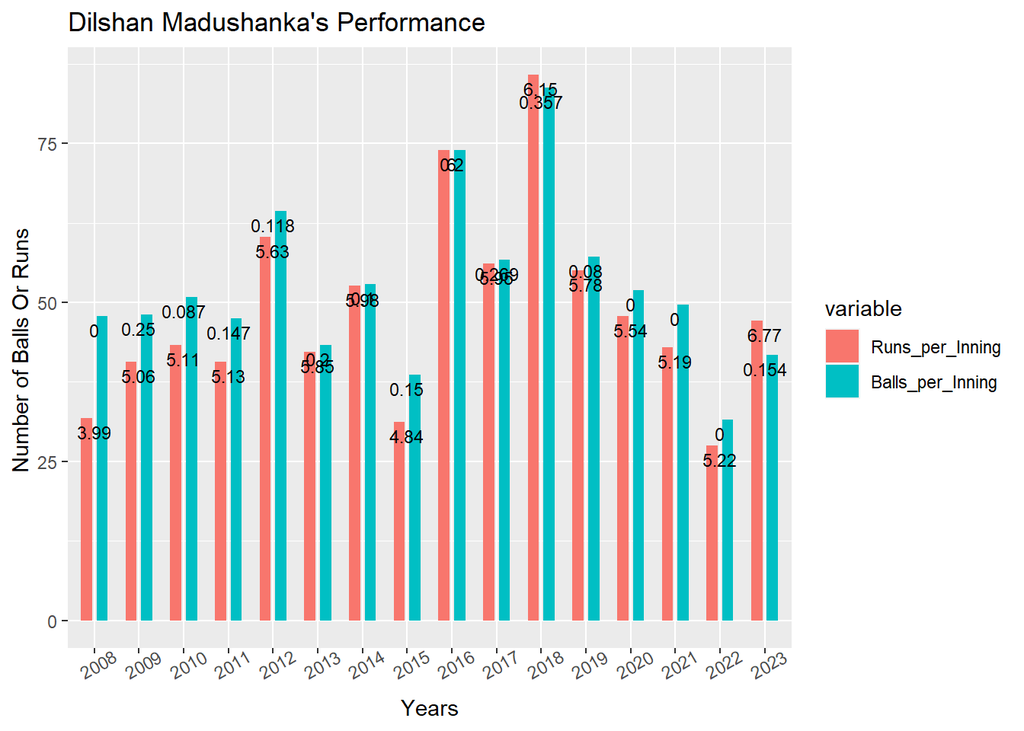

In this plot x axis shows the no of year , y axis shows the number of balls or baised on bar means for red bar it is run and for skyblue bar its ball , no the text on red bar are strike rate and on skyblue bar is the probablity to be out in a inning .

#### 5.4.2 World Map Plot

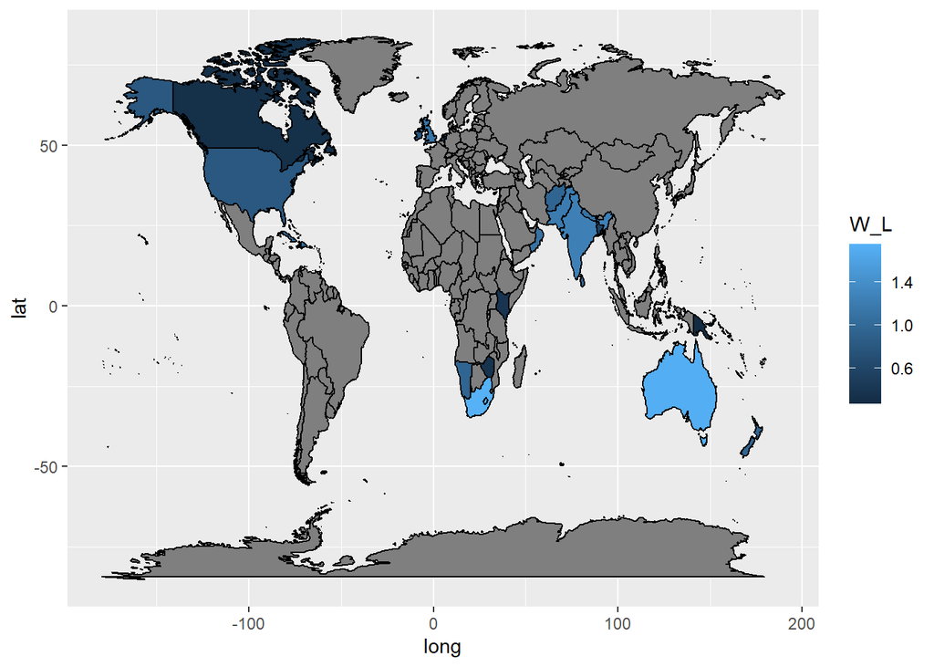

This plot shows the win looss ratio of the team which is in coloured country on map and density of colour shows the high win loosse ratio .

#### 5.4.3 Match Up Plot

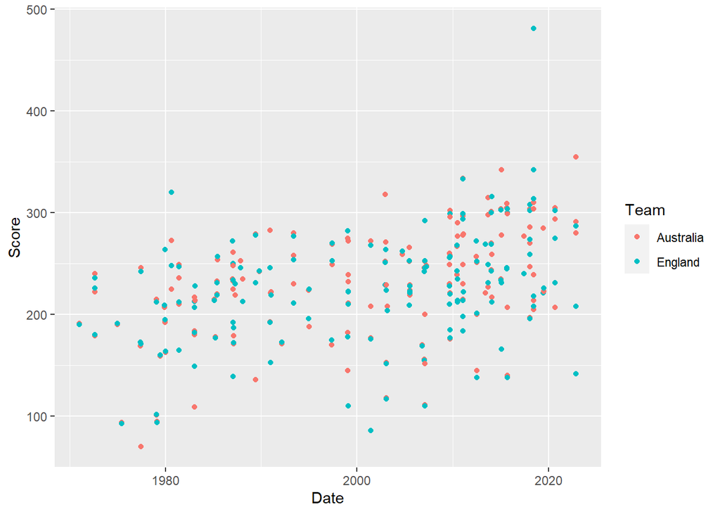

This plot shows the result of previous year matches x axis is the year and y axis shows the score and red and skyblue point are for different country .

#### 5.4.4 Country-Specific View

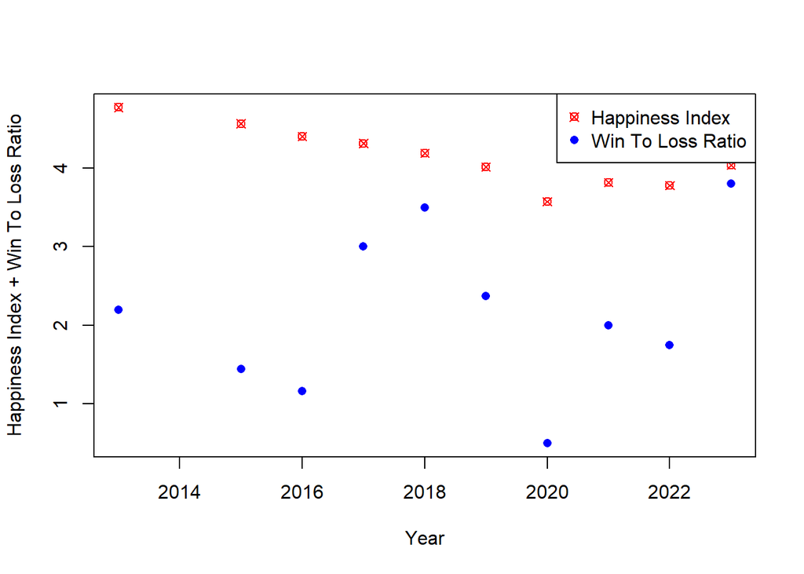

This plot shows the combine view of happines index and winloos ratio .

#### 5.4.5 A barplot showing GDP

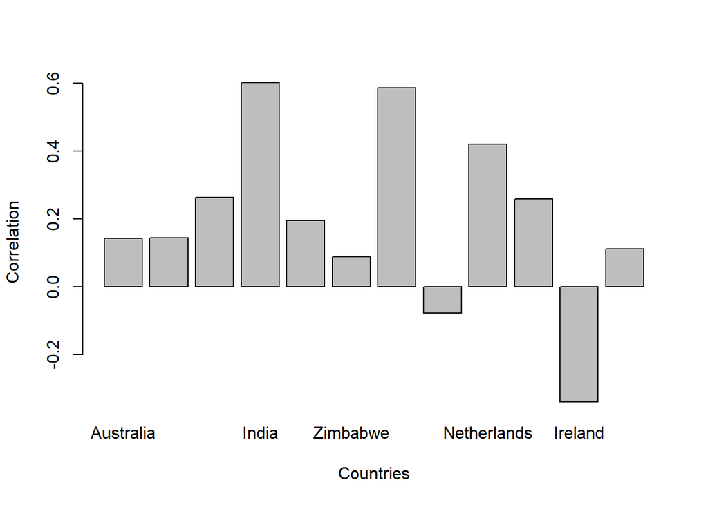

#### 5.4.6 A plotly shoing batsman data

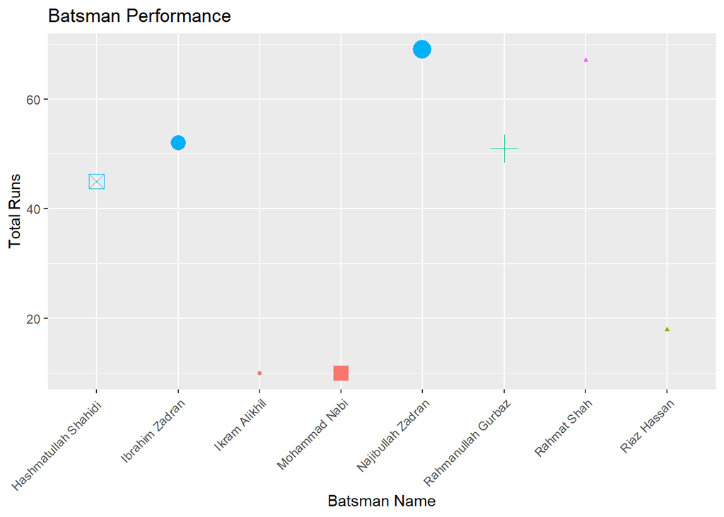

This plot shows the result of batsman as visualisation x bar shows the name of player and y bar shows the total run hit by a player shape shows who has taken the wicket , color shows no of Four, size shows No of Six. This plot is in ploty but in pdf cant be shown so to see deiscribed plot please refer to html document .

#### 5.4.7 A pie plot showing bowler data in match

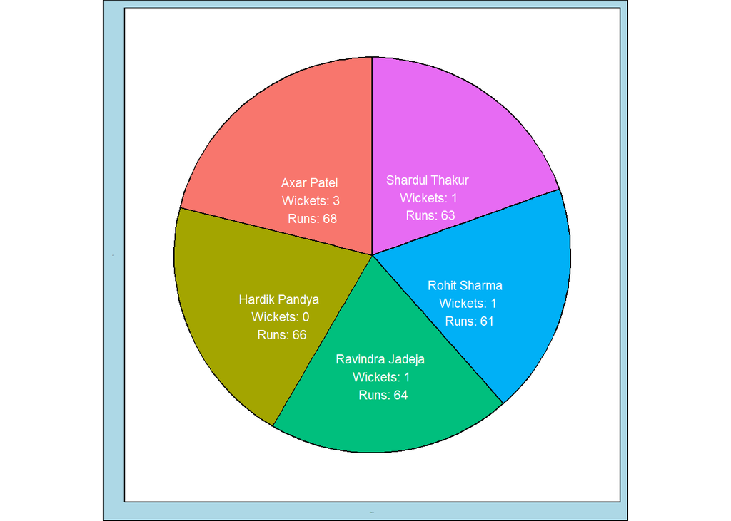

This pie plot shows the bowlers outcome in a match all detail are described in it .

## 6. Conclusions

Access to individual player information throughout their career is a fantastic feature, especially for cricket fans who want to dig deep into player statistics and achievements. This can improve the overall cricketing experience. The ability to run live simulations with default teams or custom lineups is an appealing feature. It allows users to test strategies, create dream teams, and experience the excitement of live matches within the app. Displaying win-loss ratios for different countries in the ODI World Cup adds a competitive element to the app. Users can compare their customized team’s performance to that of real-world national teams. Being capable to access summaries of previous encounters between two sides provides historical context. It allows users to research rivalries and historical events in cricket. Viewing a team’s past performance, along with graphs, is a useful feature for those interested in in-depth analysis. It enables users to make data-driven decisions and understand team trends. It’s interesting to see the correlation between GDP per capita, Happiness Index, and win-loss ratios of World Cup countries. It gives the app an educational and analytical dimension, appealing to users who are interested in the broader societal impact on sports performance.

## 7. References

- Dataset scraped from [CricMetic](http://www.cricmetric.com/index.py)
- [R documentation](https://www.r-project.org/other-docs.html) was very useful for finding functions in base R.